# Almetyevsk metagenome statistics 2

Oxana Kolpakova

2023-12-02

## 1. Обработка данных fastq

- fastp -q 20 -l 50 –trim_poly_g
- kraken2 Confidence 0.1, Minimum Base Quality 20, Standart DB (Galaxy)
- Kraken taxonomic report (Galaxy)

## 2. Фильтрация

Определим процентное содержания фрагментов генома человека в образцах.

```
##   Sample Human_ratio
## 1     S1 0.002099184
## 2     S2 0.002572213
## 3     S3 0.002489128
## 4     S4 0.001569696
```

Контаминации фрагментами генома человека незначительна.

## 3. Определение самых представленных видов.

Создадим таблицы из 15 самых представленных видов

[output not shown]

Создадим список уникальных видов из предыдущих таблиц.

|  | DescriptiveSpecies |
| --- | --- |
| 1 | s__Methanohalophilus_portucalensis |
| 2 | s__Methanohalophilus_halophilus |
| 3 | s__Methanolobus_zinderi |
| 4 | s__Geoalkalibacter_subterraneus |
| 5 | s__Marinobacter_salarius |
| 6 | s__Halothiobacillus_halophilus |
| 7 | s__Marinobacter_hydrocarbonoclasticus |
| 8 | s__Marinobacter_similis |
| 9 | s__Pseudomonas_balearica |
| 10 | s__Pseudomonas_stutzeri |
| 11 | s__Halomonas_meridiana |
| 12 | s__Desulfovibrio_marinus |
| 13 | s__Marinobacter_sp._LV10R510-11A |
| 14 | s__delta_proteobacterium_PL12 |
| 15 | s__Thiobacillus_prosperus |
| 26 | s__Halomonas_sp._A3H3 |
| 27 | s__Halorhodospira_halochloris |
| 30 | s__delta_proteobacterium_PP31 |
| 35 | s__Marinobacter_salsuginis |
| 36 | s__Marinobacterium_georgiense |
| 45 | s__Halanaerobium_hydrogeniformans |
| 60 | s__Desulfococcus_multivorans |

Всего получилось 22 уникальных вида.

## 4. Типичный предствитель S1

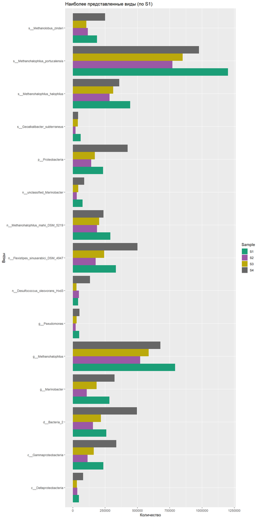

Simpson’s Diversity Index (Индекс Симпсона):

Измеряет вероятность двух прочтений, выбранных случайным образом, принадлежать к разным таксонам. Chao1 (Индекс Чао1):

Оценивает общее количество таксонов в сообществе, включая те, которые не были обнаружены (унайденные). Observed OTUs (Наблюдаемые OTU):

Просто подсчитывает количество уникальных операциональных таксонов в сообществе. Inverse Simpson’s Index (Инверсия индекса Симпсона):

Мера доминирования, обратная к индексу Симпсона. Более высокие значения указывают на большее доминирование.

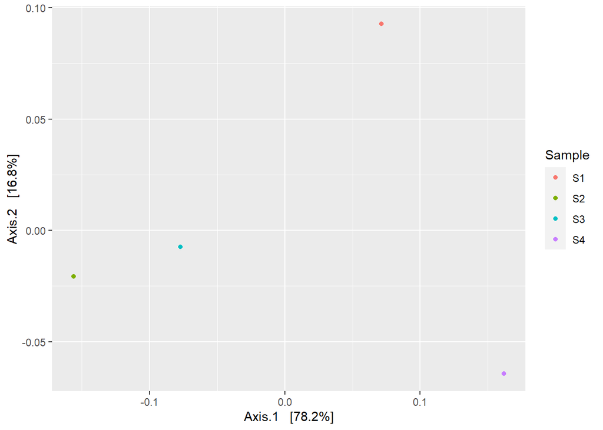

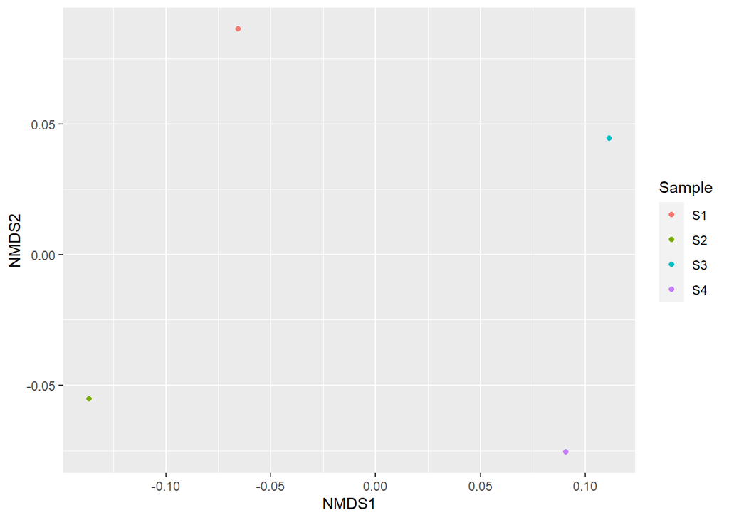